# Check 3: Academic patterns

Conducting the analysis with stateELP

Guide home | Previous: Check 2: On-time vs. prolonged exiters | Next: Check 4: Decision consistency

**Simulated data**

Every output on this page comes from the package’s simulated data. It shows what this step produces and how to read it. It says nothing about any real state: every gap, ratio and rate here comes from how the data were generated.

```r
library(stateELP)
```

Check 3 sets English learners’ (ELs’) content-test scores beside their English language proficiency (ELP), grade by grade, with former ELs and never-EL students as reference groups.

## What this step answers

**At what level of English proficiency does language stop being the main thing holding back performance on the content test? And is the bar the state sets one that English-only peers clear themselves?**

The state’s *proficiency cut* is the lowest scale score of the academic level the state calls proficient. If at least half the students in an ELP band reach it, students at that level of English perform on the content test the way the state expects of anyone. If they do not, the content test may still be measuring their English along with their subject knowledge.

That level is then set against the exit threshold. Students who exit below it leave while the content test is still partly a language test for them. A threshold well above it holds students longer than the state’s own content standard requires.

The step answers this three ways for each grade and subject: **box plots** of scores by ELP band; a **logistic regression** of the chance of reaching the cut, read at the ELP score where that chance is 50%; and **landing statistics** that put the grades side by side. Two **fairness checks** then ask whether English-only peers clear the same bar.

## Sample

**Cross-sectional: every current EL in one grade who has a score on one content test in one school year, plus former ELs and English-only students in the same grade, subject and year.**

Checks 1 and 2 follow one entry cohort (students who entered EL status in the same grade and year) forward through time. Check 3 takes a one-year snapshot instead. It includes every EL in the grade, whenever they entered, so recent arrivals sit beside students in their sixth year of status.

- **A student is in the sample because they sat the content test.** The package starts from the academic table and attaches roster status to it. Starting from the roster or the ELP table would drop the reference groups. An untested student is outside this sample, not missing from it.
- **Each grade and subject is its own *panel*. Grades are never pooled.** The simulated spec declares ELA and Math in grades 3 through 11. Each panel uses the most recent year with academic scores.
- **The groups** are current ELs split into ELP bands (the spec’s grouping of the reported proficiency level), current ELs with no annual ELP score that year, former ELs, and English-only students (`EL_STATUS == "never"`). A former EL is never counted as English-only.
- **In the simulated data**, former ELs leave the data four years after exiting, so “Former ELs” means former within four years. English-only students are a 10% sample with a `SAMPLE_WEIGHT` of 10.
- **The logistic regression uses current ELs only.** No one else has an ELP score to regress on.

## Status in the package

**Built.** Every output slot the stage’s instruction file lists is filled, including the check for multi-criterion rules. The stage’s tests have no skips, and its report renders to Word and HTML. Four things are not built:

- **A matched English-only group.** Fairness check (a) *filters* on one free-or-reduced-price lunch flag (`FRL`). Matching is a recorded later addition.
- **A year dimension.** Each panel takes the most recent year only.
- **A display of the multi-criterion check** in the stage report. Read it from the results object (last section).
- **A “screened but not classified” group.** The instruction file describes it as a spec-gated column (empty for the simulated data). No slot or column exists for it yet.

## Before you start

You need an `el_spec` and an `el_data` bundle that includes the academic table. Check 3 reads these parts of the spec:

| Spec field | What Check 3 uses it for |
| --- | --- |
| `academic$<subject>$grades` | Which grades get a panel. A subject with `grades = NULL` (an end-of-course test) takes its grades from the data. |
| `academic$<subject>$cuts` and `policy$academic_benchmark$proficient_level` | The proficiency cut: the red line, the share at or above it, and the logistic outcome. |
| `elp$bands` | The band columns and their order. |
| `elp$administration_window` | The note on how the two tests are paired in time. |
| `policy$exit` | The band the exit threshold falls in, and the rule’s Type. |
| `policy$suppression$min_cell` | The smallest group whose statistics are shown. |

```r
spec <- read_el_spec("00_SIM_EL_Spec")

spec_academic_subjects(spec)
```

```
[1] "ELA"  "Math"
```

```r
spec_academic_grades(spec, "ELA")
```

```
[1] "3"  "4"  "5"  "6"  "7"  "8"  "9"  "10" "11"
```

```r
spec$academic$ELA$cuts                        # minimum score of levels 2 to 5
```

```
[1] 700 735 750 790
```

```r
spec$policy$academic_benchmark$proficient_level
```

```
[1] 4
```

```r
spec_headline_label(spec)                     # the ELP score the exit rule uses
```

```
[1] "Overall Composite"
```

```r
spec$elp$administration_window
```

```
[1] "Jan-Mar"
```

```r
spec_min_cell(spec)
```

```
[1] 10
```

Here the cut is level 4’s minimum, 750. The simulated cuts carry `source = "provisional"`, the spec’s form of `[DERIVED — VERIFY]`. For a real state, take them from an official table.

Build the bundle once and reuse it:

```r
bundle <- as_el_data(el_long_sim,
                     roster   = el_roster_sim,
                     academic = academic_long_sim,
                     spec     = spec)
nrow(el_academic(bundle))
```

```
[1] 568202
```

A missing input never stops the stage. The affected slots come back `NULL` or empty:

[output not shown]

## Run it

One call computes every panel:

```r
res <- run_check3(bundle, spec)
names(res)
```

```
[1] "box_data"              "summary_table"         "logistic"
[4] "landing"               "fairness_boxes"        "fairness_logistic"
[7] "contested_zone_models" "coverage"              "meta"
```

On the simulated data this takes a minute or two: it fits two logistic regressions in each of 18 panels. Read the sample statement first. It names the panel the stage report draws:

```r
cat(res$meta$sample)
```

Cross-sectional, and different from Data Checks 1 and 2: **every grade-3 EL with a 2025 ELA score** – not the entry cohort those stages follow – with former ELs and an English-only group beside them for reference. A student enters on having sat the content test, so the universe is the ELA table joined to roster status, not the other way round. Each grade is a panel of its own and grades are never pooled; this pass renders grade 3, the first grade the spec declares ELA tested in.

### How the panel is chosen

Grade, subject and year are derived, never typed. `compute_panel()` takes the first subject in the spec’s `academic` block, its first declared grade, and the most recent year the data carry scores for that pairing:

```r
str(compute_panel(bundle, spec))
```

```
List of 4
 $ subject: chr "ELA"
 $ grade  : chr "3"
 $ year   : int 2025
 $ years  : int [1:10] 2015 2016 2017 2018 2019 2021 2022 2023 2024 2025
```

`years` lists the years available. 2020 is absent because the simulated data have no academic scores that year. It is a missing year, not an empty one, so asking for it returns `NULL` rather than a figure with zero students:

```r
gap <- compute_panel(bundle, spec, year = 2020L)
compute_box_data(bundle, spec, gap)
```

### Looking at another grade or subject

Every panel is already in `res`. The figure and table helpers take `subject` and `grade` selectors:

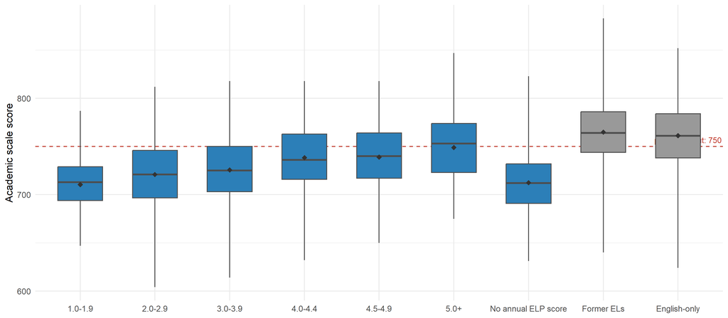

```r
plot_box_panel(res$box_data, spec, subject = "Math", grade = "8")
```

`run_check3()` also takes `subject`, `grade` and `year`. `subject` limits the run to one subject, `grade` sets which panel comes first (and so which one the stage report draws), and `year` applies to every panel:

```r
res_math <- run_check3(bundle, spec, subject = "Math", grade = "8")
```

For one panel alone, pass `compute_panel()` output to a compute function:

```r
p <- compute_panel(bundle, spec, subject = "Math", grade = "8")
compute_logistic(bundle, spec, p)[, c("SUBJECT", "GRADE", "YEAR", "N",
                                      "CROSSING", "CROSSING_IN_RANGE")]
```

```
# A tibble: 1 × 6
  SUBJECT GRADE  YEAR     N CROSSING CROSSING_IN_RANGE
  <chr>   <chr> <int> <int>    <dbl> <lgl>
1 Math    8      2025  1260     470. TRUE
```

## What you get

| Slot | What it holds | One row per |
| --- | --- | --- |
| `$box_data` | The five box statistics, the mean and the counts for each group | panel × group |
| `$summary_table` | The same numbers as a table, plus the interquartile range (IQR) | panel × group |
| `$logistic` | The fitted curve and its 50% crossing | panel |
| `$landing` | Where each panel lands, by band and by crossing | panel |
| `$fairness_boxes` | `$box_data` with the English-only group filtered to economically disadvantaged students | panel × group |
| `$fairness_logistic` | The logistic refitted against the English-only average | panel |
| `$contested_zone_models` | The multi-criterion check; `NULL` here | — |
| `$coverage` | Counts by year and grade: who has which scores | year × grade |
| `$meta` | The sample statement, the focal panel, the cut, and two notes | — |

The table slots are keyed by `SUBJECT`, `GRADE` and `YEAR`. None holds student rows.

### The box plot

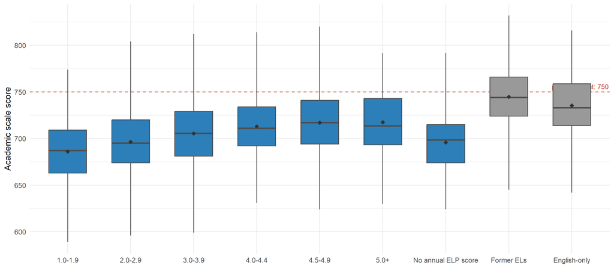

ELA scale score by ELP band, grade 3, 2025. Grey boxes are reference groups, not bands; the blue ‘No annual ELP score’ column is not a band either. The diamond is the mean and the dashed red line is the proficiency cut.

```r
plot_box_panel(res$box_data, spec)
```

Boxes run from the 25th to the 75th percentile, with the median across them; whiskers reach the minimum and maximum. The figure is drawn from precomputed statistics, so it always matches the table. A suppressed group keeps its place as a gap; an empty group is left off.

“No annual ELP score” holds current ELs who were untested that year or took the alternate ELP form, whose levels are on another scale (148 students here). They keep their own column so the panel loses no one.

### The summary table

```r
ft_check3_summary(res)
```

| Group | n | n scored | Min | 25th | Median | Mean | 75th | Max | IQR | At/above cut |
| --- | --- | --- | --- | --- | --- | --- | --- | --- | --- | --- |
| 1.0-1.9 | 253 | 253 | 589 | 663 | 687 | 686 | 709 | 774 | 46 | 3% |
| 2.0-2.9 | 481 | 481 | 596 | 674 | 695 | 696 | 720 | 804 | 46 | 6% |
| 3.0-3.9 | 744 | 744 | 599 | 681 | 706 | 705 | 729 | 812 | 48 | 11% |
| 4.0-4.4 | 529 | 529 | 631 | 692 | 711 | 713 | 734 | 814 | 42 | 13% |
| 4.5-4.9 | 415 | 415 | 624 | 694 | 717 | 717 | 741 | 820 | 47 | 19% |
| 5.0+ | 174 | 174 | 630 | 693 | 714 | 718 | 743 | 792 | 50 | 21% |
| No annual ELP score | 148 | 138 | 624 | 674 | 698 | 696 | 715 | 792 | 41 | 4% |
| Former ELs | 383 | 383 | 645 | 724 | 744 | 745 | 766 | 832 | 42 | 43% |
| English-only | 426 | 426 | 642 | 714 | 733 | 735 | 759 | 816 | 45 | 35% |

`N` counts everyone in the group. `N_PLOTTED` (“n scored”) counts the scores the statistics rest on. Students on an alternate academic assessment (`N_ALTERNATE`) are in `N` but out of the distribution, because their scores are on another scale. Suppression keys on `N_PLOTTED`. `PCT_AT_CUT` (“At/above cut”) is the share at or above the cut. Three columns sit in the slot but not in the table:

```r
foc[, c("GROUP", "N", "N_PLOTTED", "N_ALTERNATE", "N_WEIGHTED", "SUPPRESSED")]
```

```
# A tibble: 9 × 6
  GROUP                   N N_PLOTTED N_ALTERNATE N_WEIGHTED SUPPRESSED
  <chr>               <int>     <int>       <int>      <dbl> <lgl>
1 1.0-1.9               253       253           0        253 FALSE
2 2.0-2.9               481       481           0        481 FALSE
3 3.0-3.9               744       744           0        744 FALSE
4 4.0-4.4               529       529           0        529 FALSE
5 4.5-4.9               415       415           0        415 FALSE
6 5.0+                  174       174           0        174 FALSE
7 No annual ELP score   148       138          10        148 FALSE
8 Former ELs            383       383           0        383 FALSE
9 English-only          426       426           0       4260 FALSE
```

The English-only group’s 426 students are a sample standing for 4,260 (`N_WEIGHTED`). Use the weighted figure when you describe its size. `SUPPRESSED` is `TRUE` below `min_cell`. The statistics are then `NA` and the row stays.

### The logistic regression and its crossing

`compute_logistic()` fits whether each current EL reached the cut against their ELP scale score. `CROSSING` is the ELP score where the fitted probability passes 50%: the language level at which a student is as likely as not to clear the content bar.

```r
res$logistic |>
  dplyr::select(SUBJECT, GRADE, N, N_ABOVE, CROSSING, CROSSING_LO,
                CROSSING_HI, CROSSING_IN_RANGE) |>
  head(9)
```

```
# A tibble: 9 × 8
  SUBJECT GRADE     N N_ABOVE CROSSING CROSSING_LO CROSSING_HI CROSSING_IN_RANGE
  <chr>   <chr> <int>   <int>    <dbl>       <dbl>       <dbl> <lgl>
1 ELA     3      2596     298     531.        489.        574. FALSE
2 ELA     4      2102     315     556.        498.        614. FALSE
3 ELA     5      1765     257     526.        483.        570. FALSE
4 ELA     6      1607     280     511.        472.        549. FALSE
5 ELA     7      1423     302     475.        453.        497. FALSE
6 ELA     8      1270     298     491.        462.        521. FALSE
7 ELA     9      1182     326     481.        453.        509. TRUE
8 ELA     10     1082     366     483.        448.        518. TRUE
9 ELA     11      961     358     457.        441.        472. TRUE
```

- `N` students were fitted, and `N_ABOVE` of them reached the cut.
- `CROSSING` is `-INTERCEPT / SLOPE`. It is `NA` when the slope is not positive, because the curve then never rises through 50%.
- `CROSSING_LO` and `CROSSING_HI` are a 95% interval from the delta method (a standard approximation for the uncertainty of a ratio of two estimates). It is never trimmed. A wide one means the curve is being read past its data.
- `CROSSING_IN_RANGE` is `FALSE` when the crossing lies outside the ELP scores observed in the panel. It is then an extrapolation, not a level any student was seen at.

In grade 3 ELA, 11% of the current ELs fitted reached the cut. The crossing (531) lies above the highest ELP score observed among them (459), so `CROSSING_IN_RANGE` is `FALSE`: no ELP score seen in this grade brings the fitted chance to 50%. A low share reaching the cut does not by itself put the crossing out of range; that depends on how the ELP scores spread. Across all panels, 12 of 18 crossings are out of range. `THRESHOLD` and `THRESHOLD_KIND` record the bar used. Here it is the state’s cut.

### Landing statistics

`compute_landing()` reads each panel two ways. `LANDING_BAND` is the first ELP band in which at least half the students reach the cut (equivalently, the first band whose median clears it), with `LANDING_PCT` its share. `LANDING_CROSSING` is the logistic crossing. `EXIT_BAND` is the band the exit threshold falls in, read from the exit rule, and `LANDING_AT_OR_ABOVE_EXIT` flags a landing there or higher. `TOP_BAND_PCT` is the largest share at or above the cut that any band reached, so an empty landing still says how close the panel came. The table labels it “Highest band’s share”, but it is not always the top band’s own share: in 4 of 18 panels a lower band did better.

```r
ft_check3_landing(res)
```

Where each panel lands. A dash means no band reached half. Bold marks a landing at or above the exit band.

| Subject | Grade | First band at/above the cut for half its students | Highest band's share | Logistic 50% crossing | 95% CI | Crossing within observed scores |
| --- | --- | --- | --- | --- | --- | --- |
| ELA | 3 | — | 21% | 531 | 489—574 | no |
| ELA | 4 | — | 23% | 556 | 498—614 | no |
| ELA | 5 | — | 23% | 526 | 483—570 | no |
| ELA | 6 | — | 28% | 511 | 472—549 | no |
| ELA | 7 | — | 39% | 475 | 453—497 | no |
| ELA | 8 | — | 37% | 491 | 462—521 | no |
| ELA | 9 | — | 40% | 481 | 453—509 | yes |
| ELA | 10 | — | 45% | 483 | 448—518 | yes |
| ELA | 11 | 4.5-4.9 | 50% | 457 | 441—472 | yes |
| Math | 3 | — | 24% | 530 | 487—573 | no |
| Math | 4 | — | 29% | 522 | 482—562 | no |
| Math | 5 | — | 36% | 494 | 464—525 | no |
| Math | 6 | — | 39% | 493 | 461—524 | no |
| Math | 7 | — | 41% | 490 | 458—521 | no |
| Math | 8 | 5.0+ | 52% | 470 | 447—494 | yes |
| Math | 9 | — | 37% | 514 | 456—572 | no |
| Math | 10 | 4.5-4.9 | 55% | 476 | 448—505 | yes |
| Math | 11 | 4.5-4.9 | 68% | 442 | 427—457 | yes |

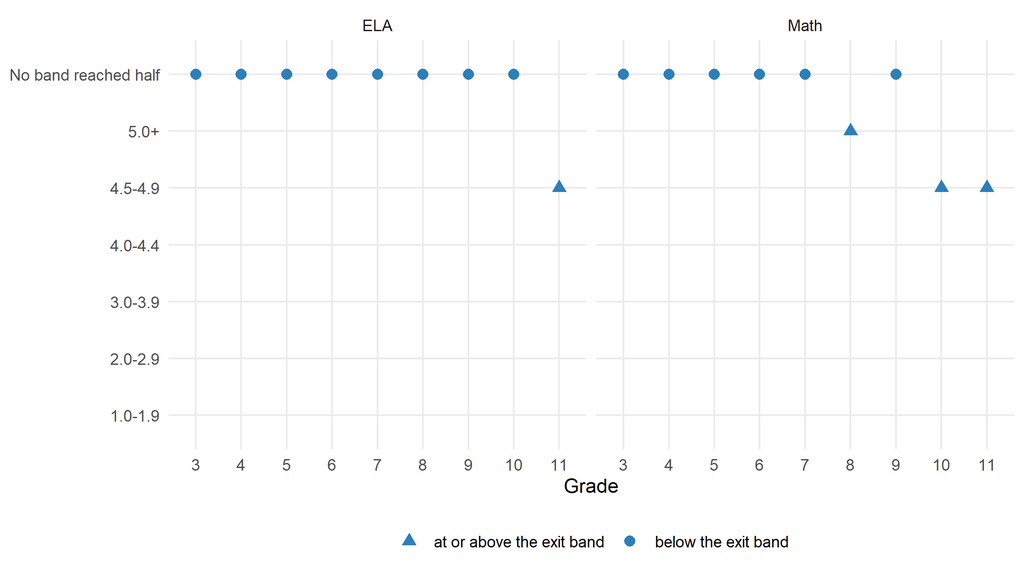

Landings read across grades. Triangles mark landings at or above the band the exit threshold falls in.

```r
plot_landing(res$landing, spec)
```

The package writes a summary sentence for this table:

```r
cat(check3_landing_note(res))
```

Of 18 grade-and-subject panels, 4 have a band where at least half the students reach the cut; in 14 no band does. **Every panel that lands, lands at or above the band the exit threshold falls in.** Those bands hold students the exit rule is about to remove, so the landing statistic there is describing a population the rule itself constitutes rather than a level students sit at and stay. The logistic crossing falls outside the ELP scores actually observed in 12 of 18 panels: there the curve is being read past its data, and the number is an extrapolation rather than a level anyone was seen at.

### The fairness checks

Both ask whether the bar set for ELs is one English-speaking peers clear themselves. Each changes one thing.

**(a) A comparable reference group.** `compute_fairness_boxes()` restricts the English-only group to economically disadvantaged students, because comparing ELs with *all* English-only students mixes up language and poverty. Nothing else changes. The filter counts an `FRL` value of `Y`, `YES`, `1`, `TRUE` or `T` (any case) as disadvantaged and everything else as not. If your delivery codes it differently (for example `F` and `R` for free and reduced), recode it first, or the filtered group comes back empty.

```r
ft_check3_summary(res, slot = "fairness_boxes")
```

| Group | n | n scored | Min | 25th | Median | Mean | 75th | Max | IQR | At/above cut |
| --- | --- | --- | --- | --- | --- | --- | --- | --- | --- | --- |
| 1.0-1.9 | 253 | 253 | 589 | 663 | 687 | 686 | 709 | 774 | 46 | 3% |
| 2.0-2.9 | 481 | 481 | 596 | 674 | 695 | 696 | 720 | 804 | 46 | 6% |
| 3.0-3.9 | 744 | 744 | 599 | 681 | 706 | 705 | 729 | 812 | 48 | 11% |
| 4.0-4.4 | 529 | 529 | 631 | 692 | 711 | 713 | 734 | 814 | 42 | 13% |
| 4.5-4.9 | 415 | 415 | 624 | 694 | 717 | 717 | 741 | 820 | 47 | 19% |
| 5.0+ | 174 | 174 | 630 | 693 | 714 | 718 | 743 | 792 | 50 | 21% |
| No annual ELP score | 148 | 138 | 624 | 674 | 698 | 696 | 715 | 792 | 41 | 4% |
| Former ELs | 383 | 383 | 645 | 724 | 744 | 745 | 766 | 832 | 42 | 43% |
| English-only | 167 | 167 | 658 | 714 | 736 | 735 | 758 | 810 | 44 | 35% |

In grade 3 ELA the English-only row drops from 426 to 167 sampled students. Its median moves from 733 to 736 and its share at or above the cut from 34.5% to 35.3%.

**(b) A different bar.** `compute_fairness_logistic()` refits the same model with the outcome “reached the English-only group’s average score” (weighted by `SAMPLE_WEIGHT`) instead of “reached the state’s cut”.

```r
ft_check3_fairness(res)
```

| Subject | Grade | State cut | English-only average | ELP crossing, state cut | ELP crossing, English-only bar | Difference |
| --- | --- | --- | --- | --- | --- | --- |
| ELA | 3 | 750 | 735 | 531 | 480 | 51 |
| ELA | 4 | 750 | 739 | 556 | 498 | 57 |
| ELA | 5 | 750 | 743 | 526 | 500 | 26 |
| ELA | 6 | 750 | 746 | 511 | 501 | 9 |
| ELA | 7 | 750 | 753 | 475 | 481 | -7 |
| ELA | 8 | 750 | 756 | 491 | 532 | -41 |
| ELA | 9 | 750 | 761 | 481 | 515 | -34 |
| ELA | 10 | 750 | 763 | 483 | 567 | -84 |
| ELA | 11 | 750 | 769 | 457 | 523 | -66 |
| Math | 3 | 750 | 737 | 530 | 474 | 56 |
| Math | 4 | 750 | 744 | 522 | 514 | 8 |
| Math | 5 | 750 | 745 | 494 | 481 | 13 |
| Math | 6 | 750 | 751 | 493 | 501 | -8 |
| Math | 7 | 750 | 755 | 490 | 500 | -10 |
| Math | 8 | 750 | 761 | 470 | 491 | -21 |
| Math | 9 | 750 | 762 | 514 | 569 | -55 |
| Math | 10 | 750 | 767 | 476 | 561 | -85 |
| Math | 11 | 750 | 773 | 442 | 556 | -114 |

“English-only average” is `THRESHOLD` in `$fairness_logistic` and “State cut” is `STATE_CUT`. Each crossing column is the ELP score where that curve passes 50%. “Difference” is the state-cut crossing minus the English-only crossing. A positive difference means the state’s cut asks for more English than reaching the English-only average would. In grade 3 ELA the English-only average is 735 against a cut of 750.

```r
cat(check3_fairness_note(res))
```

In 7 of 18 panels the English-only group’s own average score sits BELOW the state’s proficiency cut – the bar being asked of English learners is one the average English-speaking peer does not clear. Swapping the bar moves the implied ELP crossing by a median of -9 scale points. A persistent gap is a construct-validity signal, not a threshold recommendation: an ELP test measures English proficiency, and a content cut is not automatically a language-access cut. It goes to the Decision stage rather than being settled here.

### Coverage and the notes in `$meta`

`$coverage` is the data-considerations table: counts by year and grade of who has which scores.

```r
res$coverage |>
  dplyr::filter(GRADE == "3", YEAR >= 2019) |>
  dplyr::select(YEAR, N_CURRENT, N_FORMER, N_NEVER_WEIGHTED,
                N_ACADEMIC_SCORED)
```

```
# A tibble: 7 × 5
   YEAR N_CURRENT N_FORMER N_NEVER_WEIGHTED N_ACADEMIC_SCORED
  <int>     <int>    <int>            <dbl>             <int>
1  2019      2751      386             4080              3526
2  2020      2826      374             4550                 0
3  2021      2831      395             4490              3404
4  2022      2846      334             4350              3604
5  2023      2780      404             4620              3623
6  2024      2742      418             4730              3619
7  2025      2846      392             4360              3661
```

It also has `N_CURRENT_ELP` (current ELs with an annual ELP score), `N_ALTERNATE` (on the alternate ELP form) and `N_NEVER_SAMPLE` (unweighted English-only). The 2020 row shows the missing year: 2,826 current ELs enrolled in grade 3, and `N_ACADEMIC_SCORED` is 0.

`$meta` carries two notes the stage report prints:

```r
cat(res$meta$pairing_note)
```

Scores are paired within the school year, not to the day: the Overall Composite is administered Jan-Mar and the content test later in the year. A student’s language score therefore precedes their content score, which is the right order for this question but is not a controlled interval.

**Reading the band axis**

The band axis is not a proficiency gradient across a stable population. Its top end is constituted by the exit rule (Overall composite proficiency level >= 4.5): a student observed as a current EL at or above the exit threshold is, in most states, in their final year – so the highest bands hold students on their way out rather than a cross-section of highly proficient ELs. Where a state’s rule carries a second criterion, the same cells instead hold students that criterion is blocking, which is a different population again. Read the top of this axis with that in mind, and read the Former ELs column beside it.

## How to read it

**Read three things together:** the landing band, the first band whose median clears the cut (how much English is enough for this content test, in this grade and year); how that compares with the exit threshold, where a gap in either direction is the finding; and whether the English-only column clears the cut itself.

**Let the reference columns carry the weight.** Former ELs are students the exit rule has already acted on. The English-only group is the population the content test was built around. A band’s position between them says more than its position against the cut. In grade 3 ELA the share at or above the cut is 43% for former ELs, 35% for English-only students and 21% in the top band.

**An empty landing is an answer.** When no band reaches half, no observed level of English is enough on its own to make clearing the content bar more likely than not. `TOP_BAND_PCT` says how close the best band came.

**Look for agreement across grades and methods.** When the band and the crossing agree, and neighboring grades land in the same place, the evidence corroborates itself. Divergence is information too. Read it against Prep 2’s composition findings and Check 1’s attrition and selection findings: a grade with many long-term ELs, or one that lost many students, can land elsewhere for reasons unrelated to the language threshold. Never settle a divergence by picking one grade.

**Check where the landings fall.** In the simulated data, 4 of 18 panels land, and 4 of those land at or above the exit band, in cells the exit rule is about to empty. A landing there rests on students the rule is removing, so treat it with the band-axis warning in mind. In real data, a top band whose median stops rising is a cue to do the same. (In grade 3 ELA the top band’s median is 714 against 717 in the band below. The simulated scores depend on ELP level, not on how close a student is to exiting, so this gap cannot show selection either way.)

**A fairness gap is a construct-validity signal, not a threshold recommendation.** An ELP test measures English proficiency, and a content cut is not automatically a language-access cut. Record the gap for the Decision stage. Check 3 does not resolve it.

## Pitfalls

- **Never pool grades.** Do not average landings or crossings across grades or draw several panels on one axis. Use the selectors.
- **A cross-section is not growth.** A band describes this year’s students, not a path anyone took.
- **Same year is not same time.** The ELP test (Jan-Mar here) comes before the content test, at an interval no one controls.
- **2020 is missing, not zero.** Never report it as a year with no proficient students.
- **Keep the join direction.** If you rebuild anything, start from the academic table, or the reference groups disappear.
- **Report English-only sizes weighted** (`N_WEIGHTED`), or label the sample count as a sample.
- **Do not lower the suppression minimum** to make cells appear.
- **Do not read the top bands as the most proficient ELs.** Under the exit rule they are mostly students in their final year of status.
- **Do not quote an out-of-range crossing as an ELP level.** When `CROSSING_IN_RANGE` is `FALSE`, the number is an extrapolation of the fitted curve; report it as lying outside the observed scores, not as a score students reach.
- **Use official cuts.** Any cut not from an official table is `[DERIVED — VERIFY]` until checked.
- **The filtered English-only group is crude.** One lunch flag narrows the comparison; it does not make the groups comparable.
- **Simulated gaps are by construction.** Every EL and English-only gap here is a parameter of the generator. Former ELs’ advantage over English-only students is a fixed shift the generator adds, so nothing here can show that exiting causes academic gains. Present simulated output as a demonstration of the machinery, never as a finding.

## Decide before moving on

1. **Is the landing stable enough to inform a threshold?** Do the band and the crossing agree, and do grades agree? Or does the landing move by grade in ways Prep 2 and Check 1 explain? Hold any landing as provisional.
2. **Where do the standard and fairness versions land?** Record the gap between the state-cut crossing and the English-only crossing for the Decision stage.
3. **Should the English-only comparison be narrowed to economically comparable students or taken whole?** If narrowed, which variable in your delivery should do it? The package filters on `FRL` only.
4. **Which grades can be read at all?** Check that each has enough students after suppression, and that the English-only group is still large enough after the economic filter.

Check 4 keeps the current ELs in this cross-section who have both an ELP level and a content score, and takes its panel from `compute_panel()`, so the grades you trust here are the ones to read there.

## Additional checks for multi-criterion exit rules

The package names six Types of exit rule: 1 a single overall composite, 2 a composite plus a floor, 3 a composite plus another source, 4 compensatory, 5 tiered or discretionary, and 6 a domain profile. Check 3’s additional check runs for Types 2, 4, 5 and 6. Check your spec’s declaration:

```r
spec_exit_types(spec)
```

```
[1] 1
```

```r
spec_has_type(spec, c(2L, 4L, 5L, 6L))
```

```
[1] FALSE
```

```r
res$contested_zone_models
```

The simulated spec is Type 1. One criterion cannot disagree with itself, so the slot is `NULL`.

Under a multi-criterion rule, the criteria disagree over a range of ELP levels, the *contested zone*, which Prep 2 finds. Inside it, Check 3 asks whether the second criterion does independent work or restates the first. `compute_contested_models()` returns:

- `$zone`: the range of ELP levels where the criteria disagree, read from Prep 2’s criteria crosswalk rather than recomputed.
- `$widen`: how far past that range the check looks, in ELP levels (0.5 by default). `$n` and `$n_cleared` count the current ELs inside.
- `$boxes`: box statistics by band, split by whether the student cleared the other criteria.
- `$model$coefficients` and `$model$curves`: one logistic with the ELP score, a cleared-the-other-criteria indicator and their interaction, and the two predicted curves it implies.
- `$source`: where the per-criterion outcomes came from. `compute_criterion_pass()` derives them from the spec’s exit terms, and a package test requires them to reproduce Prep 2’s own list of students blocked by exactly one criterion.

`run_check3()` computes this for the focal panel only. For another grade or subject, pass a panel: `compute_contested_models(bundle, spec, compute_panel(bundle, spec, subject = "Math", grade = "8"))`.

To show the shape, this code adds a hypothetical domain floor to the simulated rule, as the package’s tests do. **It is an illustration, not any state’s rule.** For a real state, declare the rule in its spec file.

```r
spec_t2 <- spec
spec_t2$policy$exit$types <- 2L
spec_t2$policy$exit$pathways[[1]]$terms <- c(
  spec_t2$policy$exit$pathways[[1]]$terms,
  list(list(component = "listening", measure = "level", op = ">=",
            value = 3.5, exempt_if_absent = FALSE)))
spec_t2 <- validate_el_spec(spec_t2)

cz <- compute_contested_models(bundle, spec_t2)
cz$criteria
```

```
[1] "overall level >= 4.5"   "listening level >= 3.5"
```

```r
cz$boxes[, c("GROUP", "CLEARED", "N", "Y_MEDIAN", "PCT_AT_CUT", "SUPPRESSED")]
```

```
# A tibble: 7 × 6
  GROUP   CLEARED                          N Y_MEDIAN PCT_AT_CUT SUPPRESSED
  <chr>   <chr>                        <int>    <dbl>      <dbl> <lgl>
1 2.0-2.9 blocked by another criterion   291      699     0.0550 FALSE
2 2.0-2.9 cleared the other criteria      71      695     0.0423 FALSE
3 3.0-3.9 blocked by another criterion   127      708     0.157  FALSE
4 3.0-3.9 cleared the other criteria     617      705     0.100  FALSE
5 4.0-4.4 blocked by another criterion     4       NA    NA      TRUE
6 4.0-4.4 cleared the other criteria     525      711     0.128  FALSE
7 4.5-4.9 cleared the other criteria     415      717     0.190  FALSE
```

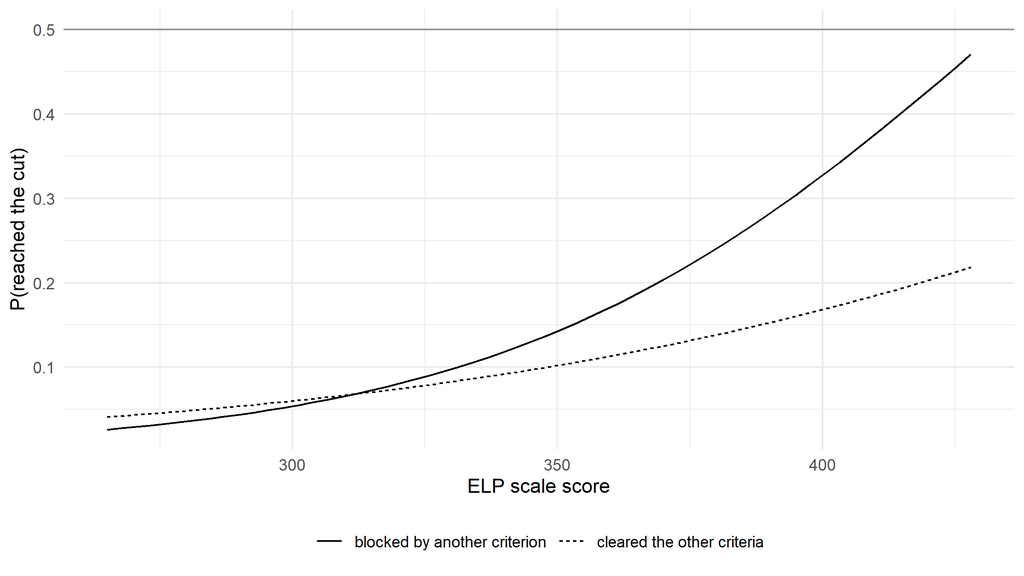

Illustration only. The two predicted curves under a hypothetical composite-plus-floor rule, grade 3 ELA.

```r
ggplot2::ggplot(cz$model$curves,
                ggplot2::aes(ELP_SCALE, FITTED, linetype = CLEARED_LABEL)) +
  ggplot2::geom_line() +
  ggplot2::geom_hline(yintercept = 0.5, colour = "grey60") +
  ggplot2::labs(x = "ELP scale score", y = "P(reached the cut)",
                linetype = NULL) +
  ggplot2::theme_minimal() +
  ggplot2::theme(legend.position = "bottom")
```

Curves that separate mean the second criterion sorts students in a way the main ELP score does not. Curves that coincide mean it restates the first. Here the rule is invented and the scores are simulated, so whether these curves separate says nothing about any real floor.

## Render the stage report

The stage report shows the same results with the stage’s own interpretive text. `render_step()` writes Word and HTML to `reports/` and scans the output for student identifiers:

```r
render_step("check3")                       # check3_academics.docx and .html
render_step("check3", formats = "html")     # HTML only
```

The example report on the simulated data is on the project site.

On its own, `render_step()` builds the stage from the simulated data. For your delivery, save your results, render from them, and run the disclosure scan against your own bundle. The report renders in a temporary folder, so give the spec file as a full path:

```r
res <- run_check3(my_bundle, my_spec)
dir.create("results", showWarnings = FALSE)
saveRDS(res, "results/check3_results.rds")   # keep out of the shared folder

files <- render_step("check3",
                     spec_file        = normalizePath("specs/XX_EL_Spec.R"),
                     results_file     = "results/check3_results.rds",
                     check_disclosure = FALSE)
check_output_disclosure(files, my_bundle)
```

Guide home | Previous: Check 2: On-time vs. prolonged exiters | Next: Check 4: Decision consistency